# Data prep for website

Karol Nowicki-Osuch

2021-02-25

This script visualizes the full dataset as well as highlighting the sub-populations in the gland cells.

# Read in the data

```r
library(scran)
library(scater)
library(DropletUtils)
library(openxlsx)
library(Rtsne)
library(pheatmap)
library(viridis)
library(sceasy) #devtools::install_github("cellgeni/sceasy")
library(reticulate)
# library(umap)

source("~/Dropbox/Postdoc/git/BEOrigin/Analysis/Functions/auxiliary.R")

set.seed(123456)
```

# All data

Here I prepare tSNE and data in format that is identical to figure S8 after batch correction. This data has little annotation but is important for review of all samples.

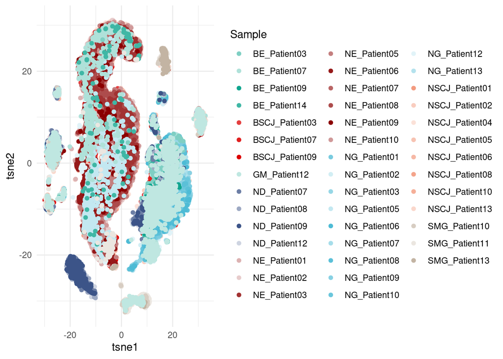

```r
# Read in the normalized and batch-corrected reads
sce.list <- readRDS("~/Dropbox/Postdoc/2019-12-29_BE2020/All_sce_filtered.rds")

# Order sce objects for batch correction
sce.list <- sce.list[order(unlist(lapply(sce.list, ncol)), decreasing = TRUE)]

n <- names(sce.list)
sce.list <- sce.list[c(which(grepl("NSCJ", n)), which(grepl("BSCJ", n)),
                       which(grepl("NE", n)), which(grepl("NG", n)),
                       which(grepl("BE", n)), which(grepl("ND", n)),
                       which(grepl("SMG", n)), which(grepl("GM", n)))]

# Remove all unecessary rowData prior to merging
sce.list <- lapply(sce.list, function(n){
  rowData(n) <- rowData(n)[,1:3]
  n
})

#merge datasets
sce.all <- do.call("cbind", sce.list)

# Batch correction
corrected <- batch.correction(sce.list)

# Save batch corrected counts in metdata
metadata(sce.all)$corrected <- corrected

# Compute new tSNE
# set.seed(11111)
tsne <- Rtsne(t(corrected), pca = FALSE, perplexity = 250)
# Store tsne in slot
reducedDims(sce.all)$TSNE <- tsne$Y[,1:2]

annot <- paste(colData(sce.all)$Tissue, colData(sce.all)$Patient, sep = "_")

annot.col <- vector(length = length(unique(annot)))
names(annot.col) <- unique(annot)
annot.col[grepl("NE", names(annot.col))] <- colorRampPalette(c("white", "darkred"))(21)[c(5,7,9,11,13,15,17,19,21)]
annot.col[grepl("NSCJ", names(annot.col))] <- colorRampPalette(c("white", "#F39B7FFF"))(21)[c(7,9,11,13,15,17,19,21)]
annot.col[grepl("BSCJ", names(annot.col))] <- colorRampPalette(c("white", "#DC0000FF"))(17)[c(13,15,17)]
annot.col[grepl("BE", names(annot.col))] <- colorRampPalette(c("white", "#00A087FF"))(17)[c(6,9,13,16)]
annot.col[grepl("ND", names(annot.col))] <- colorRampPalette(c("white", "#3C5488FF"))(17)[c(5,9,13,17)]
annot.col[grepl("NG", names(annot.col))] <- colorRampPalette(c("white", "#4DBBD5FF"))(25)[c(5,7,9,11,13,15,17,19,21,23,25)]
annot.col[grepl("SMG", names(annot.col))] <- colorRampPalette(c("white", "#B09C85FF"))(17)[c(5,9,13)]
annot.col[grepl("GM", names(annot.col))] <- colorRampPalette(c("white", "#00A087FF"))(17)[c(5)]

tsne.corrected <- ggplot(data.frame(tsne1 = tsne$Y[,1], tsne2 = tsne$Y[,2],
                                    Sample = annot)) +
  geom_point(aes(tsne1, tsne2, colour = Sample)) + scale_colour_manual(values = annot.col) + theme_minimal()
tsne.corrected
```

```r
sceasy:::convertFormat(sce.all, from="sce", to="anndata",
                       outFile="/home/karolno/Dropbox/Postdoc/2019-12-29_BE2020/Website_data/alldata.h5ad")
```

```
## AnnData object with n_obs × n_vars = 50569 × 58395
##     obs: 'Sample', 'Barcode', 'Patient', 'Tissue', 'total_features_by_counts', 'log10_total_features_by_counts', 'total_counts', 'log10_total_counts', 'pct_counts_in_top_50_features', 'pct_counts_in_top_100_features', 'pct_counts_in_top_200_features', 'pct_counts_in_top_500_features', 'Clusters'
##     var: 'ID', 'Symbol'
##     obsm: 'X_tsne'
```

```r
saveRDS(sce.all, "~/Dropbox/Postdoc/2019-12-29_BE2020/Website_data/alldata.rds")
```

# All good data

Here I prepare tSNE and data in format that is identical to figure 3A after batch correction. This data has all annotation about cell types, tissue and my confidence into the assigned tissue type.

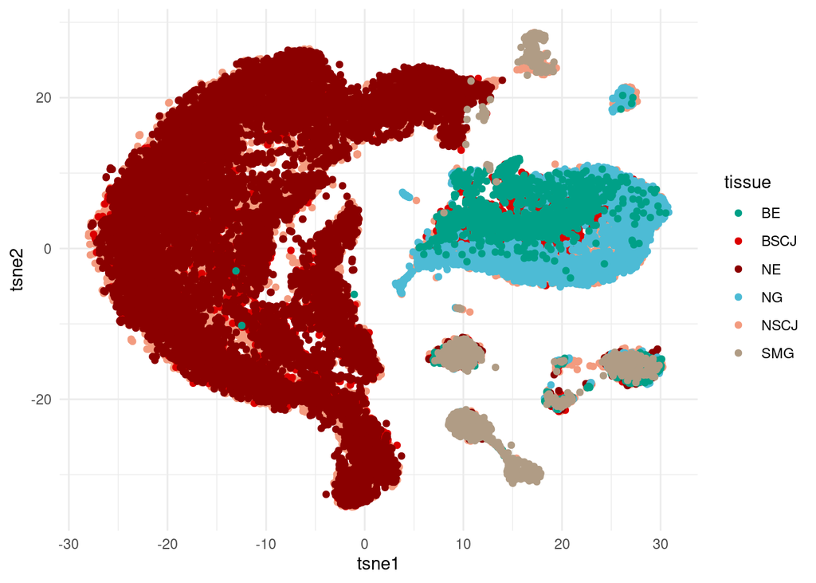

```r
# Read in the normalized and batch-corrected reads (only from good samples)
sce <- readRDS("~/Dropbox/Postdoc/2019-12-29_BE2020/All_corrected_sce_filtered.rds")

# Exclude contaminating cells
sce <- sce[,sce$include]

# Exclude duodenum cells
sce <- sce[,colData(sce)$Tissue != "ND"]


n <- names(sort(table(sce[["Sample"]]), decreasing = TRUE))
n <- n[c(which(grepl("NSCJ_out", n)), which(grepl("BSCJ_out", n)),
         which(grepl("NE_out", n)), which(grepl("NG_out", n)),
         which(grepl("BE_out", n)), which(grepl("SMG_out", n)))]
sce<-batchelor::multiBatchNorm(sce, batch = sce[["Sample"]])
# The samples are in NSCJ, NE, NG, SMG order
corrected <- batch.correction.single(sce, batches = "Sample", m.order = n)

# Save batch corrected counts in metdata
metadata(sce)$corrected <- corrected

# Compute new tSNE
set.seed(1234)
tsne <- Rtsne(t(corrected), pca = FALSE, perplexity = 250)

reducedDims(sce)<-NULL
reducedDims(sce)$TSNE <- tsne$Y


tsne.corrected <- ggplot(data.frame(tsne1 = tsne$Y[,1], tsne2 = tsne$Y[,2],
                                    tissue = colData(sce)$Tissue)) +
  geom_point(aes(tsne1, tsne2, colour = tissue)) + scale_color_manual(values = metadata(sce)$colour_vector) + theme_minimal()
tsne.corrected
```

```r
sceasy:::convertFormat(sce, from="sce", to="anndata",
                       outFile="/home/karolno/Dropbox/Postdoc/2019-12-29_BE2020/Website_data/alldatahighquality.h5ad")
```

```
## AnnData object with n_obs × n_vars = 39882 × 58395
##     obs: 'Sample', 'Barcode', 'Patient', 'Tissue', 'total_features_by_counts', 'log10_total_features_by_counts', 'total_counts', 'log10_total_counts', 'pct_counts_in_top_50_features', 'pct_counts_in_top_100_features', 'pct_counts_in_top_200_features', 'pct_counts_in_top_500_features', 'Clusters',…
##     var: 'ID', 'Symbol'
##     obsm: 'X_tsne'
```

```r
saveRDS(sce, "~/Dropbox/Postdoc/2019-12-29_BE2020/Website_data/alldatahighquality.rds")
```

# SMG data

Here I prepare tSNE and data in format that is identical to figure 1C after batch correction. This data has all annotation about cell types, tissue and my confidence into the assigned tissue type.

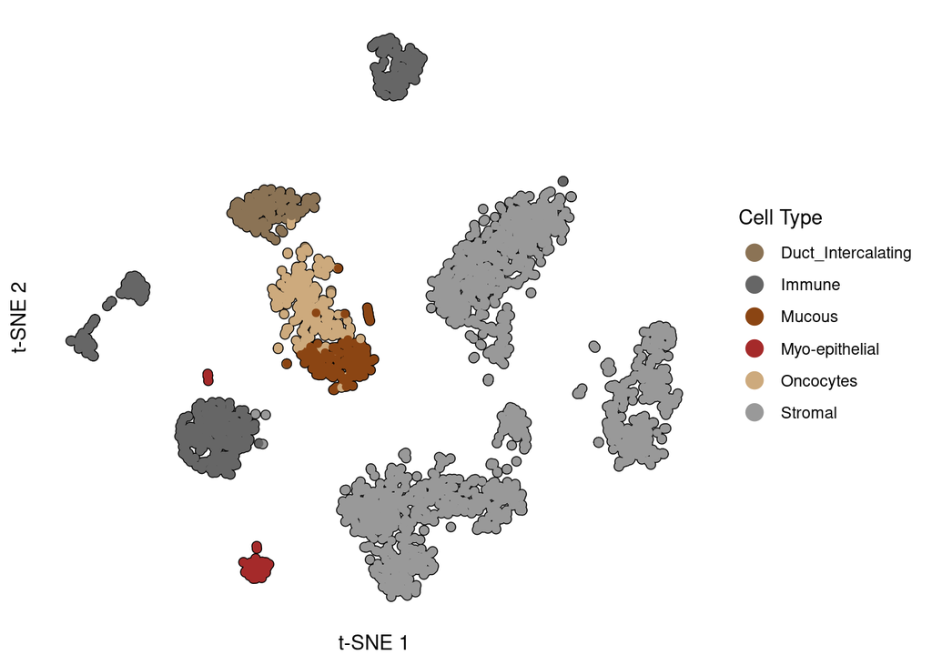

```r
# Read in the normalized and batch-corrected reads (only from good samples)
sce <- readRDS("~/Dropbox/Postdoc/2019-12-29_BE2020/All_corrected_sce_filtered.rds")

# Select only SMG cells
cur_sce <- sce[,sce$Tissue == "SMG" & sce$include]

# Perform batch scaling
cur_sce<-batchelor::multiBatchNorm(cur_sce, batch = cur_sce[["Sample"]])

# batch correction
batch.order<-order(table(cur_sce[["Sample"]]), decreasing = TRUE)
corrected <- batch.correction.single(cur_sce, batches = "Sample", m.order = batch.order)

# Compute tSNE for gland cells
set.seed(111)
smg_tsne <- Rtsne(t(corrected), pca = FALSE)

# Save batch corrected counts in metdata
metadata(cur_sce)$corrected <- corrected

reducedDims(cur_sce)<-NULL
reducedDims(cur_sce)$TSNE <- smg_tsne$Y

# Create colour vecotr for glands
colour_vector <-  vector(length = length(unique(cur_sce$cell_type)))
names(colour_vector) <- unique(cur_sce$cell_type)
colour_vector["Immune"] <- "grey40"
colour_vector["Unknown.Doublets"] <- "white"
colour_vector["Mucous"] <- "saddlebrown"
colour_vector["Oncocytes"] <- "burlywood3"
colour_vector["Stromal"] <- "grey60"
# colour_vector["Nonepithelial"] <- "grey80"
colour_vector["Duct_Intercalating"] <- "burlywood4"
colour_vector["Squamous_Esophagus"] <- "black"
colour_vector["Myo-epithelial"] <- "brown"
# colour_vector["Dendritic"] <- "grey20"

p.smg <- ggplot(data.frame(tsne1 = smg_tsne$Y[,1],
                           tsne2 = smg_tsne$Y[,2],
                           cell_type = as.factor(cur_sce$cell_type))) +
  geom_point(aes(tsne1, tsne2), colour = "black", size = 2) +
  geom_point(aes(tsne1, tsne2, colour = cell_type)) +
  scale_color_manual(values = colour_vector) +
  theme(panel.grid.major = element_blank(),
        panel.grid.minor = element_blank(),
        panel.background = element_blank(),
        axis.line = element_blank(),
        axis.text = element_blank(),
        axis.ticks = element_blank(),
        legend.background = element_blank(),
        legend.key = element_blank()
  ) +
  xlab("t-SNE 1")  +
  ylab("t-SNE 2") +
  guides(colour = guide_legend(override.aes = list(size=4), title = "Cell Type")
  )

p.smg
```

```r
sceasy:::convertFormat(cur_sce, from="sce", to="anndata",
                       outFile="/home/karolno/Dropbox/Postdoc/2019-12-29_BE2020/Website_data/SMG.h5ad")
```

```
## AnnData object with n_obs × n_vars = 2744 × 58395
##     obs: 'Sample', 'Barcode', 'Patient', 'total_features_by_counts', 'log10_total_features_by_counts', 'total_counts', 'log10_total_counts', 'pct_counts_in_top_50_features', 'pct_counts_in_top_100_features', 'pct_counts_in_top_200_features', 'pct_counts_in_top_500_features', 'Clusters', 'Global_c…
##     var: 'ID', 'Symbol'
##     obsm: 'X_tsne'
```

```r
saveRDS(cur_sce, "~/Dropbox/Postdoc/2019-12-29_BE2020/Website_data/SMG.rds")
```

# NSCJ data

Here I prepare tSNE and data in format that is identical to figure 2A after batch correction. This data has all annotation about cell types, tissue and my confidence into the assigned tissue type.

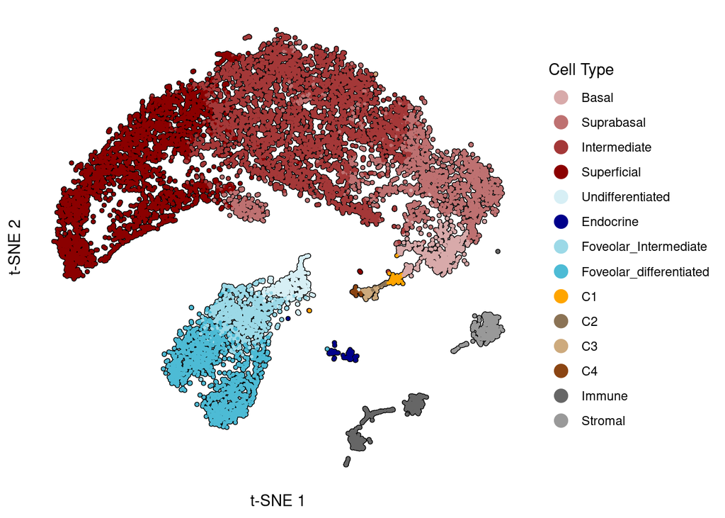

```r
# Read in the normalized and batch-corrected reads (only from good samples)
sce <- readRDS("~/Dropbox/Postdoc/2019-12-29_BE2020/All_corrected_sce_filtered.rds")
sce <- sce[,sce$include]

# Change cell type names for the paper
sce$cell_type[sce$cell_type == "KRT5_cells"]<-"C1"
sce$cell_type[sce$cell_type == "KRT5.KRT7_cells"]<-"C2"
sce$cell_type[sce$cell_type == "KRT7_cells"]<-"C3"
sce$cell_type[sce$cell_type == "MUC5B_cells"]<-"C4"


sce$cell_type <- factor(sce$cell_type, levels = c(
  "Basal",
  "Suprabasal",
  "Intermediate",
  "Superficial",

  "Undifferentiated",
  "Endocrine",
  "Foveolar_Intermediate",
  "Foveolar_differentiated",
  "Parietal",
  "Chief",

  "Columnar_Undifferentiated",
  "Columnar_Intermediate",
  "Columnar_differentiated",

  "Enterocytes_Intermediate",
  "Enterocytes_differentiated",
  "Paneth",

  "Goblet",

  "C1",
  "C2",
  "C3",
  "C4",

  "Mucous",
  "Oncocytes",
  "Duct_Intercalating",
  "Myo-epithelial",
  "Unknown.Doublets",

  "Immune",
  "Stromal",
  "Squamous_Esophagus",
  "Novel"
))

cur_sce <- sce[,sce$include & sce$Tissue %in% c("NSCJ")]
cur_sce<-batchelor::multiBatchNorm(cur_sce, batch = cur_sce[["Sample"]])

# Perform batch correction
batch.order<-order(table(cur_sce[["Sample"]]), decreasing = TRUE)
corrected <- batch.correction.single(cur_sce, batches = "Sample", m.order = batch.order)
# Compute new tSNE
set.seed(12345)
tsne <- Rtsne(t(corrected), pca = FALSE, perplexity = 100)

# Save batch corrected counts in metdata
metadata(cur_sce)$corrected <- corrected

reducedDims(cur_sce)<-NULL
reducedDims(cur_sce)$TSNE <- tsne$Y

# Cell type
colour_vector <- vector(length = length(unique(cur_sce$cell_type)))
names(colour_vector) <- unique(cur_sce$cell_type)
colour_vector["Superficial"] <- colorRampPalette(c("white", "dark red"))(10)[10]
colour_vector["Basal"] <- colorRampPalette(c("white", "dark red"))(10)[4]
colour_vector["Suprabasal"] <- colorRampPalette(c("white", "dark red"))(10)[6]
colour_vector["Intermediate"] <- colorRampPalette(c("white", "dark red"))(10)[8]

colour_vector["Foveolar_differentiated"] <- colorRampPalette(c("white", "#4DBBD5FF"))(10)[10]
colour_vector["Endocrine"] <- colorRampPalette(c("white", "dark blue"))(10)[10]
colour_vector["Undifferentiated"] <- colorRampPalette(c("white", "#4DBBD5FF"))(10)[3]
colour_vector["Foveolar_Intermediate"] <- colorRampPalette(c("white", "#4DBBD5FF"))(10)[6]
colour_vector["Immune"] <- "grey40"
colour_vector["Stromal"] <- "grey60"

# colour_vector["Novel"] <- "orange"

colour_vector["C4"] <- "saddlebrown"
colour_vector["C3"] <- "burlywood3"
colour_vector["C2"] <- "burlywood4"
colour_vector["C1"] <- "orange"



p.all.cells.cell_type_all <- ggplot(data.frame(tsne1 = reducedDims(cur_sce)$TSNE[,1],
                                               tsne2 = reducedDims(cur_sce)$TSNE[,2],
                                               tissue = colData(cur_sce)$cell_type)) +
  geom_point(aes(tsne1, tsne2), colour = "black", size = 1) +
  geom_point(aes(tsne1, tsne2, colour = tissue), size = 0.5) +
  scale_color_manual(values = colour_vector) +
  theme(panel.grid.major = element_blank(),
        panel.grid.minor = element_blank(),
        panel.background = element_blank(),
        axis.line = element_blank(),
        axis.text = element_blank(),
        axis.ticks = element_blank(),
        legend.background = element_blank(),
        legend.key = element_blank()) +
  xlab("t-SNE 1")  +
  ylab("t-SNE 2") +
  guides(colour = guide_legend(override.aes = list(size=4), title = "Cell Type"))

p.all.cells.cell_type_all
```

```r
sceasy:::convertFormat(cur_sce, from="sce", to="anndata",
                       outFile="/home/karolno/Dropbox/Postdoc/2019-12-29_BE2020/Website_data/NSCJ.h5ad")
```

```
## AnnData object with n_obs × n_vars = 11702 × 58395
##     obs: 'Sample', 'Barcode', 'Patient', 'total_features_by_counts', 'log10_total_features_by_counts', 'total_counts', 'log10_total_counts', 'pct_counts_in_top_50_features', 'pct_counts_in_top_100_features', 'pct_counts_in_top_200_features', 'pct_counts_in_top_500_features', 'Clusters', 'Global_c…
##     var: 'ID', 'Symbol'
##     obsm: 'X_tsne'
```

```r
saveRDS(cur_sce, "~/Dropbox/Postdoc/2019-12-29_BE2020/Website_data/NSCJ.rds")
```

# NE data

Here I prepare tSNE and data in format that is identical to figure S9A after batch correction. This data has all annotation about cell types, tissue and my confidence into the assigned tissue type.

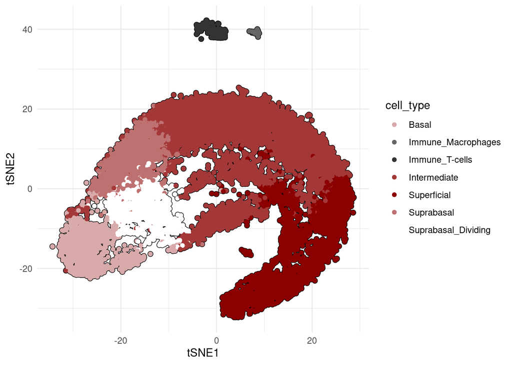

```r
# Read in the normalized and batch-corrected reads (only from good samples)
sce <- readRDS("~/Dropbox/Postdoc/2019-12-29_BE2020/All_corrected_sce_filtered.rds")

# Remove contaminating cell-types
sce <- sce[,sce$include]

# Select NE data
cur_sce <- sce[,sce$Tissue == "NE"]

# Split the samples to perform batch correction
sce.list <- split.sce(cur_sce, unique(cur_sce$Sample), colData.name = "Sample")

# Order sce object by size
sce.list <- sce.list[order(unlist(lapply(sce.list, ncol)), decreasing = TRUE)]


cur_sce <- do.call("cbind", sce.list)
corrected <- batch.correction(sce.list)

# Compute tSNE
set.seed(12345)
tsne <- Rtsne(t(corrected), pca = FALSE, perplexity = 100)

# Save batch corrected counts in metdata
metadata(cur_sce)$corrected <- corrected

reducedDims(cur_sce)<-NULL
reducedDims(cur_sce)$TSNE <- tsne$Y

# Create colour vector
colour_vector <- vector(length = length(unique(cur_sce$cell_type_secondary)))
names(colour_vector) <- unique(cur_sce$cell_type_secondary)
colour_vector["Immune_T-cells"] <- "grey20"
colour_vector["Immune_Macrophages"] <- "grey40"

colour_vector["Superficial"] <- colorRampPalette(c("white", "dark red"))(10)[10]
colour_vector["Basal"] <- colorRampPalette(c("white", "dark red"))(10)[4]
colour_vector["Suprabasal"] <- colorRampPalette(c("white", "dark red"))(10)[6]
colour_vector["Intermediate"] <- colorRampPalette(c("white", "dark red"))(10)[8]
colour_vector["Suprabasal_Dividing"] <- colorRampPalette(c("white", "dark red"))(10)[1]

tsne.NE <- ggplot(data.frame(tSNE1 = tsne$Y[,1],
                             tSNE2 = tsne$Y[,2],
                             cell_type = cur_sce$cell_type_secondary)) +
  geom_point(aes(tSNE1, tSNE2), colour = "black", size = 2) +
  geom_point(aes(tSNE1, tSNE2, colour = cell_type)) +
  scale_color_manual(values = colour_vector) + theme_minimal()
tsne.NE
```

```r
sceasy:::convertFormat(cur_sce, from="sce", to="anndata",
                       outFile="/home/karolno/Dropbox/Postdoc/2019-12-29_BE2020/Website_data/NE.h5ad")
```

```
## AnnData object with n_obs × n_vars = 16663 × 58395
##     obs: 'Sample', 'Barcode', 'Patient', 'total_features_by_counts', 'log10_total_features_by_counts', 'total_counts', 'log10_total_counts', 'pct_counts_in_top_50_features', 'pct_counts_in_top_100_features', 'pct_counts_in_top_200_features', 'pct_counts_in_top_500_features', 'Clusters', 'Global_c…
##     var: 'ID', 'Symbol'
##     obsm: 'X_tsne'
```

```r
saveRDS(cur_sce, "~/Dropbox/Postdoc/2019-12-29_BE2020/Website_data/NE.rds")
```

# NG data

Here I prepare tSNE and data in format that is identical to figure S9C after batch correction. This data has all annotation about cell types, tissue and my confidence into the assigned tissue type.

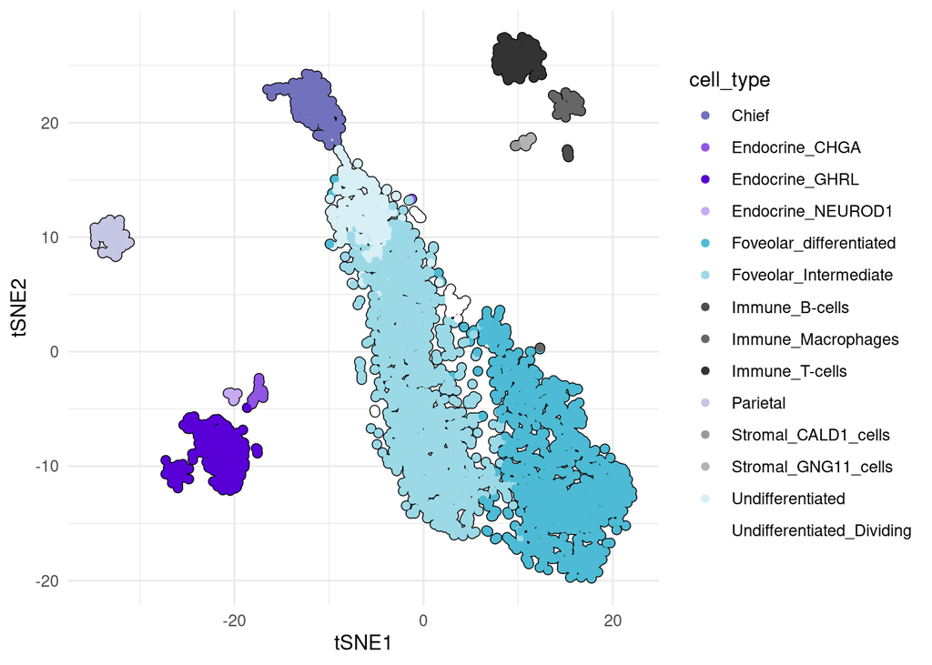

```r
# Read in the normalized and batch-corrected reads (only from good samples)
sce <- readRDS("~/Dropbox/Postdoc/2019-12-29_BE2020/All_corrected_sce_filtered.rds")

# Remove contaminating cell-types
sce <- sce[,sce$include]

# Select NG cells
cur_sce <- sce[,sce$Tissue == "NG"]

# Split the samples to perform batch correction
sce.list <- split.sce(cur_sce, unique(cur_sce$Sample), colData.name = "Sample")
# Order sce object by size
sce.list <- sce.list[order(unlist(lapply(sce.list, ncol)), decreasing = TRUE)]

cur_sce <- do.call("cbind", sce.list)
corrected <- batch.correction(sce.list)

# Compute tSNE
set.seed(12345)
tsne <- Rtsne(t(corrected), pca = FALSE, perplexity = 100)

# Save batch corrected counts in metdata
metadata(cur_sce)$corrected <- corrected

reducedDims(cur_sce)<-NULL
reducedDims(cur_sce)$TSNE <- tsne$Y

# Create colour vector
colour_vector <- vector(length = length(unique(cur_sce$cell_type_secondary)))
names(colour_vector) <- unique(cur_sce$cell_type_secondary)
# colour_vector["Immune"] <- "grey40"
# colour_vector["Stromal"] <- "grey60"
colour_vector["Immune_T-cells"] <- "grey20"
colour_vector["Immune_B-cells"] <- "grey30"
colour_vector["Immune_Macrophages"] <- "grey40"
colour_vector["Stromal_CALD1_cells"] <- "grey60"
colour_vector["Stromal_GNG11_cells"] <- "grey70"


colour_vector["Foveolar_differentiated"] <- colorRampPalette(c("white", "#4DBBD5FF"))(10)[10]
colour_vector["Undifferentiated"] <- colorRampPalette(c("white", "#4DBBD5FF"))(10)[3]
colour_vector["Foveolar_Intermediate"] <- colorRampPalette(c("white", "#4DBBD5FF"))(10)[6]
colour_vector["Chief"] <- colorRampPalette(c("white", "dark blue"))(10)[6]
colour_vector["Parietal"] <- colorRampPalette(c("white", "dark blue"))(10)[3]
colour_vector["Undifferentiated_Dividing"] <- colorRampPalette(c("white", "dark blue"))(10)[1]

colour_vector["Endocrine_GHRL"] <- colorRampPalette(c("white", "#5900D8FF"))(10)[10]
colour_vector["Endocrine_CHGA"] <- colorRampPalette(c("white", "#5900D8FF"))(10)[7]
colour_vector["Endocrine_NEUROD1"] <- colorRampPalette(c("white", "#5900D8FF"))(10)[4]


tsne.GC <- ggplot(data.frame(tSNE1 = tsne$Y[,1],
                             tSNE2 = tsne$Y[,2],
                             cell_type = cur_sce$cell_type_secondary)) +
  geom_point(aes(tSNE1, tSNE2), colour = "black", size = 2) +
  geom_point(aes(tSNE1, tSNE2, colour = cell_type)) +
  scale_color_manual(values = colour_vector) + theme_minimal()
tsne.GC
```

```r
sceasy:::convertFormat(cur_sce, from="sce", to="anndata",
                       outFile="/home/karolno/Dropbox/Postdoc/2019-12-29_BE2020/Website_data/NG.h5ad")
```

```
## AnnData object with n_obs × n_vars = 4039 × 58395
##     obs: 'Sample', 'Barcode', 'Patient', 'total_features_by_counts', 'log10_total_features_by_counts', 'total_counts', 'log10_total_counts', 'pct_counts_in_top_50_features', 'pct_counts_in_top_100_features', 'pct_counts_in_top_200_features', 'pct_counts_in_top_500_features', 'Clusters', 'Global_c…
##     var: 'ID', 'Symbol'
##     obsm: 'X_tsne'
```

```r
saveRDS(cur_sce, "~/Dropbox/Postdoc/2019-12-29_BE2020/Website_data/NG.rds")
```

# ND data

Here I prepare tSNE and data in format that is identical to figure S9E after batch correction. This data has all annotation about cell types, tissue and my confidence into the assigned tissue type.

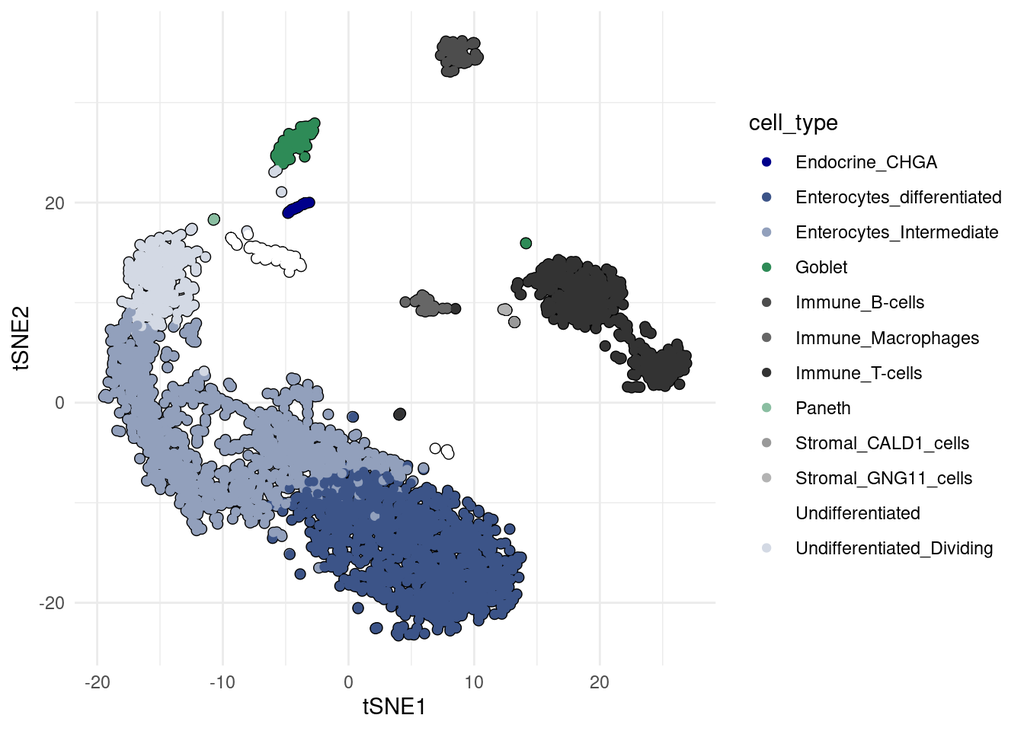

```r
# Read in the normalized and batch-corrected reads (only from good samples)
sce <- readRDS("~/Dropbox/Postdoc/2019-12-29_BE2020/All_corrected_sce_filtered.rds")

# Remove contaminating cell-types
sce <- sce[,sce$include]

# Select ND cells
cur_sce <- sce[,sce$Tissue == "ND"]

# Split the samples to perform batch correction
sce.list <- split.sce(cur_sce, unique(cur_sce$Sample), colData.name = "Sample")
# Order sce object by size
sce.list <- sce.list[order(unlist(lapply(sce.list, ncol)), decreasing = TRUE)]

cur_sce <- do.call("cbind", sce.list)
corrected <- batch.correction(sce.list)

# Compute tSNE
set.seed(12345)
tsne <- Rtsne(t(corrected), pca = FALSE, perplexity = 100)

# Save batch corrected counts in metdata
metadata(cur_sce)$corrected <- corrected

reducedDims(cur_sce)<-NULL
reducedDims(cur_sce)$TSNE <- tsne$Y

# Create colour vector
colour_vector <- vector(length = length(unique(cur_sce$cell_type_secondary)))
names(colour_vector) <- unique(cur_sce$cell_type_secondary)
colour_vector["Immune_T-cells"] <- "grey20"
colour_vector["Immune_B-cells"] <- "grey30"
colour_vector["Immune_Macrophages"] <- "grey40"
colour_vector["Stromal_CALD1_cells"] <- "grey60"
colour_vector["Stromal_GNG11_cells"] <- "grey70"

colour_vector["Enterocytes_Intermediate"] <- colorRampPalette(c("white", "#3C5488FF"))(10)[6]
colour_vector["Enterocytes_differentiated"] <- colorRampPalette(c("white", "#3C5488FF"))(10)[10]
colour_vector["Undifferentiated_Dividing"] <- colorRampPalette(c("white", "#3C5488FF"))(10)[3]
colour_vector["Undifferentiated"] <- colorRampPalette(c("white", "#3C5488FF"))(10)[1]
colour_vector["Goblet"] <- colorRampPalette(c("white", "seagreen4"))(10)[10]
colour_vector["Paneth"] <- colorRampPalette(c("white", "seagreen4"))(10)[6]
colour_vector["Endocrine_CHGA"] <- colorRampPalette(c("white", "dark blue"))(10)[10]

tsne.D2 <- ggplot(data.frame(tSNE1 = tsne$Y[,1],
                             tSNE2 = tsne$Y[,2],
                             cell_type = cur_sce$cell_type_secondary)) +
  geom_point(aes(tSNE1, tSNE2), colour = "black", size = 2) +
  geom_point(aes(tSNE1, tSNE2, colour = cell_type)) +
  scale_color_manual(values = colour_vector) + theme_minimal()
tsne.D2
```

```r
sceasy:::convertFormat(cur_sce, from="sce", to="anndata",
                       outFile="/home/karolno/Dropbox/Postdoc/2019-12-29_BE2020/Website_data/ND.h5ad")
```

```
## AnnData object with n_obs × n_vars = 3522 × 58395
##     obs: 'Sample', 'Barcode', 'Patient', 'total_features_by_counts', 'log10_total_features_by_counts', 'total_counts', 'log10_total_counts', 'pct_counts_in_top_50_features', 'pct_counts_in_top_100_features', 'pct_counts_in_top_200_features', 'pct_counts_in_top_500_features', 'Clusters', 'Global_c…
##     var: 'ID', 'Symbol'
##     obsm: 'X_tsne'
```

```r
saveRDS(cur_sce, "~/Dropbox/Postdoc/2019-12-29_BE2020/Website_data/ND.rds")
```

# BE data

Here I prepare tSNE and data in format that is identical to figure S10D and supplementary note SN3 after batch correction. This data has all annotation about cell types, tissue and my confidence into the assigned tissue type.

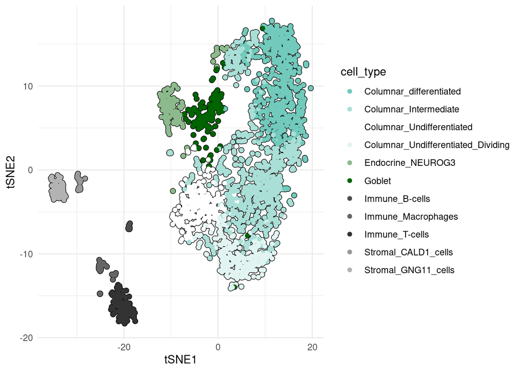

```r
# Read in the normalized and batch-corrected reads (only from good samples)
sce <- readRDS("~/Dropbox/Postdoc/2019-12-29_BE2020/All_corrected_sce_filtered.rds")

# Remove contaminating cell-types
cur_sce <- sce[,sce$Tissue == "BE" & sce$include]

# Only genes that are expressed
cur_sce <- cur_sce[Matrix::rowSums(logcounts(cur_sce)) > 0,]

# Normalization across all cells
cur_sce <- computeSumFactors(cur_sce, clusters=paste(cur_sce$cell_type_secondary))
cur_sce <- logNormCounts(cur_sce, log = TRUE)


# Split the samples to perform batch correction
sce.list <- split.sce(cur_sce, unique(cur_sce$Sample), colData.name = "Sample")
# Order sce object by size
sce.list <- sce.list[order(unlist(lapply(sce.list, ncol)), decreasing = TRUE)]

cur_sce <- do.call("cbind", sce.list)
corrected <- batch.correction(sce.list)

# Compute tSNE
set.seed(12345)
tsne <- Rtsne(t(corrected), pca = FALSE, perplexity = 100)

# Save batch corrected counts in metdata
metadata(cur_sce)$corrected <- corrected

reducedDims(cur_sce)<-NULL
reducedDims(cur_sce)$TSNE <- tsne$Y

# Create colour vector
colour_vector <- vector(length = length(unique(cur_sce$cell_type_secondary)))
names(colour_vector) <- unique(cur_sce$cell_type_secondary)
colour_vector["Immune_T-cells"] <- "grey20"
colour_vector["Immune_B-cells"] <- "grey30"
colour_vector["Immune_Macrophages"] <- "grey40"
colour_vector["Stromal_CALD1_cells"] <- "grey60"
colour_vector["Stromal_GNG11_cells"] <- "grey70"

colour_vector["Columnar_Undifferentiated"] <- "white"
colour_vector["Columnar_Undifferentiated_Dividing"] <- colorRampPalette(c("white", "#00A087FF"))(10)[2]
colour_vector["Columnar_Intermediate"] <- colorRampPalette(c("white", "#00A087FF"))(10)[4]
colour_vector["Columnar_differentiated"] <- colorRampPalette(c("white", "#00A087FF"))(10)[6]
colour_vector["Endocrine_NEUROG3"] <- colorRampPalette(c("white", "dark green"))(10)[5]
colour_vector["Goblet"] <- colorRampPalette(c("white", "dark green"))(10)[10]
colour_vector["Endocrine"] <- colorRampPalette(c("white", "dark green"))(10)[5]

tsne.BE <- ggplot(data.frame(tSNE1 = tsne$Y[,1],
                             tSNE2 = tsne$Y[,2],
                             cell_type = cur_sce$cell_type_secondary)) +
  geom_point(aes(tSNE1, tSNE2), colour = "black", size = 2) +
  geom_point(aes(tSNE1, tSNE2, colour = cell_type)) +
  theme_minimal()+
  scale_color_manual(values = colour_vector)
tsne.BE
```

```r
sceasy:::convertFormat(cur_sce, from="sce", to="anndata",
                       outFile="/home/karolno/Dropbox/Postdoc/2019-12-29_BE2020/Website_data/BE.h5ad")
```

```
## AnnData object with n_obs × n_vars = 2357 × 28131
##     obs: 'Sample', 'Barcode', 'Patient', 'total_features_by_counts', 'log10_total_features_by_counts', 'total_counts', 'log10_total_counts', 'pct_counts_in_top_50_features', 'pct_counts_in_top_100_features', 'pct_counts_in_top_200_features', 'pct_counts_in_top_500_features', 'Clusters', 'Global_c…
##     var: 'ID', 'Symbol'
##     obsm: 'X_tsne'
```

```r
saveRDS(cur_sce, "~/Dropbox/Postdoc/2019-12-29_BE2020/Website_data/BE.rds")
```